# Data Analysis BWI to JFK/EWR

Irena Austin

2026-03-10

## Step 1 Installing and loading the libraries

```r
# ============================================================
# Step 1.  Install and load libraries
# ============================================================
if (!require("pacman")) install.packages("pacman")
```

```r
pacman::p_load(
  tidyverse, janitor, lubridate, skimr,
  caret, glmnet, broom,
  ggplot2, knitr, kableExtra
)

set.seed(42)
```

**NOTE:**  
Used command “pacman” to load up all libraries at once:  
- tidyverse: collection of tools (dplyr to filter, tidyr to organize);  
- janitor: clean up tool for name clean up;  
- lubridate: time and date tool helps with extracting day of week or month;  
- skimr: quick scan of data to check how many values are missing, averages, histograms; - caret: classification and regression traing, crossvalidaton;  
- glmnet: ridge and lasso regression, used to check which varaiable is the strongest predictor;  
- broom: sweeps the messy texts in data, clean, organize data;  
- ggplot2: building charts;  
- knitr: knitting for github;  
- kableExtra: adds extra grapgics, formatting to table.  
Used set.seed(42) - to generate same random number each time to produce same result.

## Step 2 Loading the raw data from enriched_flights_2019

```r
# ============================================================
# Step 2. Load raw data set
# ============================================================
flights_raw <- read_csv("enriched_flights_2019.csv") %>%
  clean_names()
```

**NOTE:**  
clean_names() - changes column names in to coding friendly names

## Step 3 Loading the weather data, commented out since its not needed

**NOTE:**  
included this so that I can remeber how to retrieve weather data

```r
# ============================================================
# Step 3. NOAA WEATHER DATA (BWI Hourly *INSERT YEAR*)
# ============================================================
# Note: requires httr2 — run separately if needed
# library(httr2)
#
# base_url <- "https://www.ncei.noaa.gov/access/services/data/v1"
# resp <- request(base_url) |>
#   req_url_query(
#     dataset           = "global-hourly",
#     stations          = "72406093721",
#     startDate         = "2024-01-01T00:00:00", ***change dates
#     endDate           = "2024-12-31T23:59:59",
#     dataTypes         = "TMP,WND,CIG,DEW",  ***what data needed
#     format            = "csv",
#     units             = "metric",
#     includeAttributes = "true",
#     includeStationName = "true"
#   ) |>
#   req_perform()
#
# ncei_clean <- resp |> resp_body_string() |>
#   read_csv(show_col_types = FALSE) |>
#   separate(WND, into = c("w_dir","w_dir_q","w_type","w_spd","w_spd_q"), sep = ",", fill = "right") |>
#   separate(TMP, into = c("t_raw","t_q"),                                 sep = ",", fill = "right") |>
#   separate(CIG, into = c("c_height","c_q","c_det","c_cavok"),            sep = ",", fill = "right") |>
#   mutate(
#     temp_c         = ifelse(t_raw   %in% c("+9999","9999"), NA, as.numeric(t_raw)  / 10),
#     wind_speed_m_s = ifelse(w_spd   == "9999",              NA, as.numeric(w_spd)  / 10),
#     wind_dir       = ifelse(w_dir   == "999",               NA, as.numeric(w_dir)),
#     ceiling_m      = ifelse(c_height == "99999",            NA, as.numeric(c_height)),
#     DATE = as.POSIXct(DATE, format = "%Y-%m-%dT%H:%M:%S", tz = "UTC")
#   ) |>
#   select(DATE, NAME, temp_c, wind_speed_m_s, wind_dir, ceiling_m)
#
# write_csv(ncei_clean, "BWI_Hourly_Weather_2024.csv")
```

```r
#NOAA library(httr2)
#library(readr)
#library(dplyr)

# base NCEI API endpoint
#base_url <- "https://www.ncei.noaa.gov/access/services/data/v1"

#query parameters according to NCEI API documentation
#req <- request(base_url) |>
# req_url_query(
#   dataset            = "global-hourly",       # Targets the ISD hourly database
#   stations           = "72406093721",         # CORRECTED: 11-digit USAF-WBAN ID #for BWI
#   startDate          = "2022-06-27T00:00:00Z",# ISO 8601 start time (Midnight UTC)
#   endDate            = "2022-06-27T23:59:59Z",# ISO 8601 end time (End of day UTC)
#   format             = "csv",                 # Requests comma-separated values
#   units              = "metric",              # Converts standard variables to #metric
#   includeAttributes  = "true",                # Includes data quality flags
#   includeStationName = "true"                 # Includes the physical station name
# )
#
# 3. Execute the request and extract the text payload
#resp <- req |> req_perform()
#csv_text <- resp |> resp_body_string()

# CSV text into an R dataframe
#ncei_hourly_datav2 <- read_csv(csv_text, show_col_types = FALSE)

# View the raw data in the console to verify all columns populated
#print(ncei_hourly_datav2)

# 5. Export the dataframe to a CSV file for Excel
#write_csv(ncei_hourly_datav2, file = "ncei_hourly_datav2_June27.csv")

# Load tidyr for the separate() function
#library(tidyr)
#library(dplyr)
#library(readr)

# Take the raw ncei_hourly_data and pass it through the cleaning pipeline
#ncei_clean <- ncei_hourly_data |>

 # --- 1. TEMPERATURE (TMP) ---
 # Format: Temperature, Quality
 #separate(TMP, into = c("temp_raw", "temp_qual"), sep = ",", remove = FALSE) |>
 #mutate(
   # Missing is "+9999". Otherwise, convert to numeric and divide by 10 for Celsius.
#   temp_c = ifelse(temp_raw == "+9999", NA, as.numeric(temp_raw) / 10)
# ) |>

 # --- 2. WIND (WND) ---
 # Format: Direction, Direction_Quality, Type, Speed, Speed_Quality
# separate(WND, into = c("wind_dir_raw", "wind_dir_qual", "wind_type", #"wind_speed_raw", "wind_speed_qual"), sep = ",", remove = FALSE) |>
# mutate(
   # Speed missing is "9999". Divide by 10 for meters per second.
#   wind_speed_m_s = ifelse(wind_speed_raw == "9999", NA, as.numeric(wind_speed_raw) / 10),
   # Direction missing is "999". Kept as whole degrees.
 #  wind_dir_deg = ifelse(wind_dir_raw == "999", NA, as.numeric(wind_dir_raw))
 #) |>

 # --- 3. CLOUD CEILING (CIG) ---
 # Format: Height, Quality, Determination, CAVOK
 #separate(CIG, into = c("ceiling_raw", "ceiling_qual", "ceiling_det", "ceiling_cavok"), sep = ",", remove = FALSE) |>
 #mutate(
   # Height missing is "99999". Kept as whole meters.
#   ceiling_height_m = ifelse(ceiling_raw == "99999", NA, as.numeric(ceiling_raw))
# ) |>

 # --- 4. SELECT FINAL FEATURES ---
 # Drop all the messy intermediate text columns so the final dataframe is lightweight
 #select(
#   DATE,
 #  temp_c,
# wind_speed_m_s,
 #  wind_dir_deg,
#   ceiling_height_m
 #)

# View the final, machine-learning-ready dataset
#print(ncei_clean)

# Export the clean dataframe to an Excel-ready CSV
#write_csv(ncei_clean, file = "NCEI_BWI_Cleanedv2_Features_June27.csv")
```

## Step 4 KARAN

**NOTES:**  
4a.  
keep_cols - looking only at specific columns  
sample_n - to pick a smaller smaple of flights, specified to 30,000 flights to ensure computer is able to process it  
mutate - ensuring its a numeric data for R to process  
delay_30 - to look at flights that are at least 30 min late  
4b.  
skim(df_sub) - quick report of data

4c.  
ggplot - added histogram to show delay distribution  
4d.  
stat_summary - shows how weather severity impacted the delay  
4e.  
summarise - to calculate delay probability for every route in database  
filter n>=50 - ignores any routes that have fewer than 50 flights  
4f.  
Logistic Regression - to predict a probability of an event, 0% to 100% of being 30 min late  
*delay_30 time + month + weather + airline + route*  
exp(coef(final_glm)) - odd ratio - if weather is 2, for every point increase in weather the chance of being late double

[output not shown]

```
## tibble [30,000 × 12] (S3: tbl_df/tbl/data.frame)
##  $ arr_delay_minutes   : num [1:30000] 0 0 5 30 0 46 0 31 0 0 ...
##  $ month               : Factor w/ 12 levels "1","2","3","4",..: 12 11 8 9 8 4 8 10 5 7 ...
##  $ day_of_week         : Factor w/ 7 levels "1","2","3","4",..: 4 7 2 5 4 5 2 7 1 2 ...
##  $ dep_time_blk        : Factor w/ 19 levels "0001-0559","0600-0659",..: 6 11 1 4 3 11 2 7 11 7 ...
##  $ distance            : num [1:30000] 842 516 1999 621 361 ...
##  $ origin              : Factor w/ 72 levels "ABQ","ALB","ATL",..: 70 28 51 46 14 3 11 14 11 3 ...
##  $ dest                : Factor w/ 72 levels "ABQ","ALB","ATL",..: 11 11 11 11 11 11 55 11 70 11 ...
##  $ reporting_airline   : Factor w/ 15 levels "9E","AA","AS",..: 9 13 13 9 2 5 13 9 9 13 ...
##  $ dep_weather_severity: num [1:30000] 0 0 0 0 0 0 0 0 0 0 ...
##  $ route               : Factor w/ 142 levels "ABQ to BWI","ALB to BWI",..: 140 98 121 116 84 3 64 84 79 3 ...
##  $ delay_30            : logi [1:30000] FALSE FALSE FALSE TRUE FALSE TRUE ...
##  $ log_delay           : num [1:30000] 0 0 1.79 3.43 0 ...
```

```r
skim(df_sub)
```

Data summary

| Name | df_sub |
| --- | --- |
| Number of rows | 30000 |
| Number of columns | 12 |
| _______________________ |  |
| Column type frequency: |  |
| factor | 7 |
| logical | 1 |
| numeric | 4 |
| ________________________ |  |
| Group variables | None |

**Variable type: factor**

| skim_variable | n_missing | complete_rate | ordered | n_unique | top_counts |
| --- | --- | --- | --- | --- | --- |
| month | 0 | 1 | FALSE | 12 | 7: 2689, 8: 2686, 12: 2622, 5: 2610 |
| day_of_week | 0 | 1 | FALSE | 7 | 3: 4440, 2: 4412, 5: 4365, 1: 4357 |
| dep_time_blk | 0 | 1 | FALSE | 19 | 060: 2575, 080: 2242, 070: 1970, 170: 1935 |
| origin | 0 | 1 | FALSE | 72 | BWI: 14882, ATL: 1039, BOS: 786, MCO: 658 |
| dest | 0 | 1 | FALSE | 72 | BWI: 15118, ATL: 955, BOS: 791, MCO: 618 |
| reporting_airline | 0 | 1 | FALSE | 15 | WN: 20164, NK: 2888, DL: 2007, AA: 1630 |
| route | 0 | 1 | FALSE | 142 | ATL: 1039, BWI: 955, BWI: 791, BOS: 786 |

**Variable type: logical**

| skim_variable | n_missing | complete_rate | mean | count |
| --- | --- | --- | --- | --- |
| delay_30 | 775 | 0.97 | 0.11 | FAL: 26143, TRU: 3082 |

**Variable type: numeric**

| skim_variable | n_missing | complete_rate | mean | sd | p0 | p25 | p50 | p75 | p100 | hist |
| --- | --- | --- | --- | --- | --- | --- | --- | --- | --- | --- |
| arr_delay_minutes | 775 | 0.97 | 11.07 | 33.31 | 0 | 0 | 0 | 5.00 | 874.00 | ▇▁▁▁▁ |
| distance | 0 | 1.00 | 802.88 | 582.50 | 90 | 369 | 611 | 936.00 | 2457.00 | ▇▇▂▁▂ |
| dep_weather_severity | 0 | 1.00 | 0.14 | 0.47 | 0 | 0 | 0 | 0.00 | 3.34 | ▇▁▁▁▁ |
| log_delay | 775 | 0.97 | 0.92 | 1.50 | 0 | 0 | 0 | 1.79 | 6.77 | ▇▁▁▁▁ |

```r
summary(df_sub$arr_delay_minutes)
```

```
##    Min. 1st Qu.  Median    Mean 3rd Qu.    Max.    NA's
##    0.00    0.00    0.00   11.07    5.00  874.00     775
```

```r
mean(is.na(df_sub$arr_delay_minutes))
```

```
## [1] 0.02583333
```

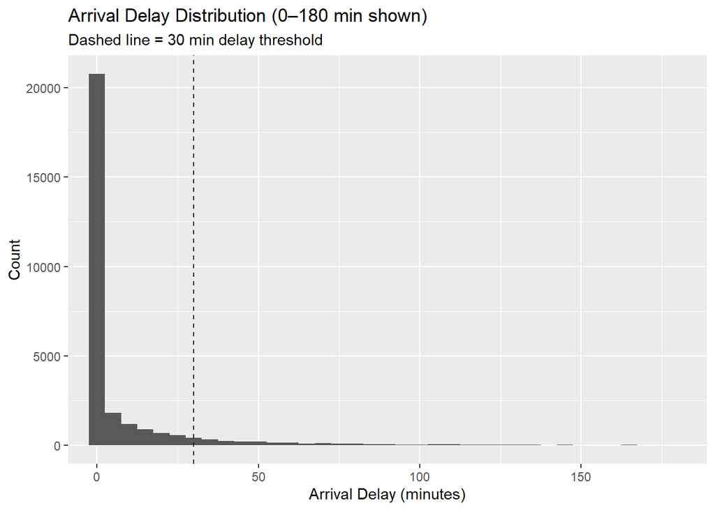

```r
# 4c. Arrival delay distribution ---
ggplot(df_sub, aes(x = arr_delay_minutes)) +
  geom_histogram(binwidth = 5) +
  coord_cartesian(xlim = c(0, 180)) +
  geom_vline(xintercept = 30, linetype = "dashed") +
  labs(
    title    = "Arrival Delay Distribution (0–180 min shown)",
    subtitle = "Dashed line = 30 min delay threshold",
    x = "Arrival Delay (minutes)", y = "Count"
  )
```

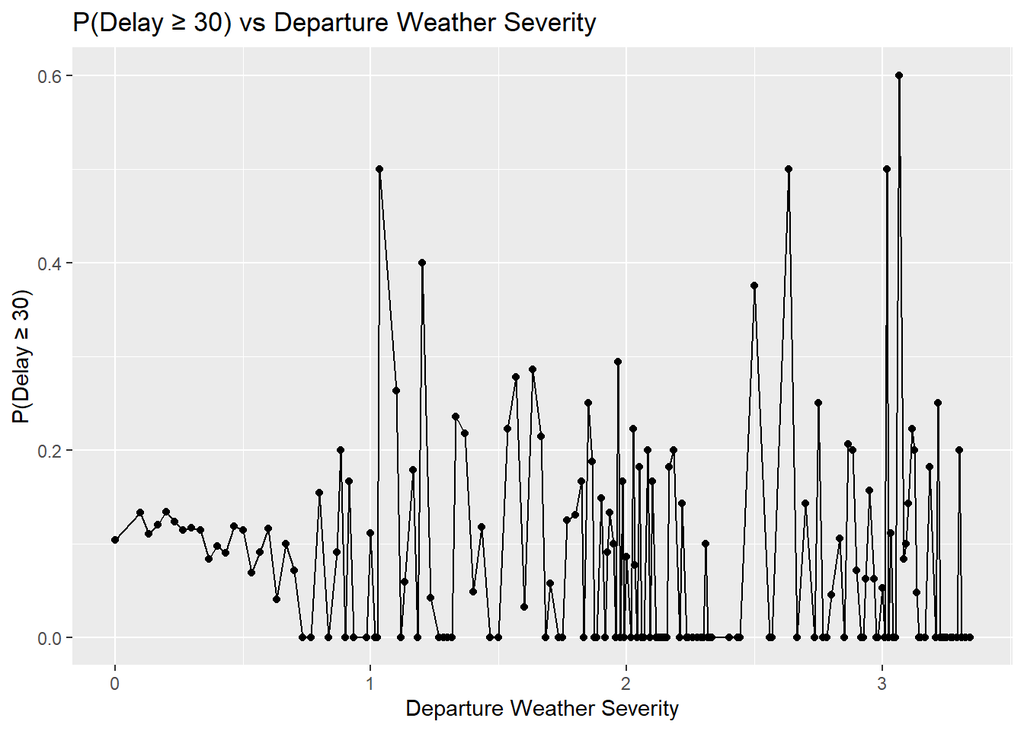

```r
# 4d. P(delay >= 30) vs weather severity ---
if ("dep_weather_severity" %in% names(df_sub)) {
  ggplot(df_sub, aes(x = dep_weather_severity, y = as.numeric(delay_30))) +
    stat_summary(fun = mean, geom = "point") +
    stat_summary(fun = mean, geom = "line") +
    labs(
      title = "P(Delay ≥ 30) vs Departure Weather Severity",
      x = "Departure Weather Severity", y = "P(Delay ≥ 30)"
    )
}
```

```r
# 4e. Top 15 routes by delay probability ---
df_sub %>%
  group_by(route) %>%
  summarise(
    n             = n(),
    p_delay30     = mean(delay_30, na.rm = TRUE),
    avg_arr_delay = mean(arr_delay_minutes, na.rm = TRUE),
    .groups = "drop"
  ) %>%
  filter(n >= 50) %>%
  arrange(desc(p_delay30)) %>%
  slice_head(n = 15)
```

```
## # A tibble: 15 × 4
##    route          n p_delay30 avg_arr_delay
##    <fct>      <int>     <dbl>         <dbl>
##  1 BWI to MIA    87     0.230          24.8
##  2 JFK to BWI   233     0.182          22.5
##  3 BWI to ALB   253     0.179          17.1
##  4 BWI to BOS   791     0.173          19.3
##  5 MIA to BWI   105     0.173          16.3
##  6 BWI to SFO   120     0.167          24.2
##  7 MYR to BWI    58     0.167          18.2
##  8 SFO to BWI   136     0.163          12.1
##  9 BWI to SMF    50     0.16           15.8
## 10 ORD to BWI   439     0.159          18.4
## 11 BOS to BWI   786     0.152          13.7
## 12 MSP to BWI   299     0.149          17.8
## 13 BWI to SDF   178     0.148          13.9
## 14 BWI to CVG   289     0.147          17.0
## 15 ABQ to BWI    75     0.147          11.4
```

```r
# 4f. Logistic regression (GLM) ---
df_glm <- df_sub %>%
  filter(!is.na(arr_delay_minutes)) %>%
  select(delay_30, dep_time_blk, month, distance,
         reporting_airline, dep_weather_severity, day_of_week, route, dest) %>%
  na.omit()

route_counts <- df_glm %>% count(route, name = "n_route")

df_glm2 <- df_glm %>%
  left_join(route_counts, by = "route") %>%
  filter(n_route >= 100) %>%
  select(-n_route)

final_glm <- glm(
  delay_30 ~ dep_time_blk + month + day_of_week + distance +
    reporting_airline + dep_weather_severity + route +
    dep_time_blk:dep_weather_severity,
  data   = df_glm2,
  family = binomial
)

summary(final_glm)
```

```
##
## Call:
## glm(formula = delay_30 ~ dep_time_blk + month + day_of_week +
##     distance + reporting_airline + dep_weather_severity + route +
##     dep_time_blk:dep_weather_severity, family = binomial, data = df_glm2)
##
## Coefficients:
##                                              Estimate Std. Error z value
## (Intercept)                                 -83.62269   78.15652  -1.070
## dep_time_blk0600-0659                        -0.06147    0.24830  -0.248
## dep_time_blk0700-0759                         0.10799    0.25007   0.432
## dep_time_blk0800-0859                         0.40744    0.24241   1.681
## dep_time_blk0900-0959                         0.63896    0.24488   2.609
## dep_time_blk1000-1059                         0.66625    0.24299   2.742
## dep_time_blk1100-1159                         0.73712    0.23720   3.108
## dep_time_blk1200-1259                         0.90588    0.24440   3.706
## dep_time_blk1300-1359                         1.01987    0.23511   4.338
## dep_time_blk1400-1459                         1.20674    0.23577   5.118
## dep_time_blk1500-1559                         1.68388    0.23145   7.275
## dep_time_blk1600-1659                         1.43061    0.23337   6.130
## dep_time_blk1700-1759                         1.65965    0.22701   7.311
## dep_time_blk1800-1859                         1.59161    0.23164   6.871
## dep_time_blk1900-1959                         1.71139    0.22885   7.478
## dep_time_blk2000-2059                         1.72159    0.22943   7.504
## dep_time_blk2100-2159                         1.75251    0.23259   7.535
## dep_time_blk2200-2259                         1.59531    0.23576   6.767
## dep_time_blk2300-2359                         1.25824    0.30868   4.076
## month2                                        0.40854    0.10928   3.738
## month3                                       -0.22904    0.11710  -1.956
## month4                                        0.29766    0.10698   2.782
## month5                                        0.50111    0.10393   4.821
## month6                                        0.63591    0.10293   6.178
## month7                                        0.71234    0.10170   7.004
## month8                                        0.61501    0.10218   6.019
## month9                                       -0.28886    0.11961  -2.415
## month10                                      -0.05876    0.11258  -0.522
## month11                                      -0.13572    0.11443  -1.186
## month12                                       0.13841    0.10835   1.277
## day_of_week2                                 -0.13614    0.07573  -1.798
## day_of_week3                                 -0.11729    0.07533  -1.557
```

[output cut: 304 more lines]

```
## dep_time_blk1900-1959:dep_weather_severity 0.540131
## dep_time_blk2000-2059:dep_weather_severity 0.537344
## dep_time_blk2100-2159:dep_weather_severity 0.516130
## dep_time_blk2200-2259:dep_weather_severity 0.517066
## dep_time_blk2300-2359:dep_weather_severity 0.724246
## ---
## Signif. codes:  0 '***' 0.001 '**' 0.01 '*' 0.05 '.' 0.1 ' ' 1
##
## (Dispersion parameter for binomial family taken to be 1)
##
##     Null deviance: 18701  on 27713  degrees of freedom
## Residual deviance: 17206  on 27544  degrees of freedom
## AIC: 17546
##
## Number of Fisher Scoring iterations: 11
```

```r
exp(coef(final_glm))   # Odds ratios
```

```
##                                (Intercept)
##                               4.820895e-37
##                      dep_time_blk0600-0659
##                               9.403840e-01
##                      dep_time_blk0700-0759
##                               1.114034e+00
##                      dep_time_blk0800-0859
##                               1.502972e+00
##                      dep_time_blk0900-0959
##                               1.894505e+00
##                      dep_time_blk1000-1059
##                               1.946927e+00
##                      dep_time_blk1100-1159
##                               2.089918e+00
##                      dep_time_blk1200-1259
##                               2.474103e+00
##                      dep_time_blk1300-1359
##                               2.772827e+00
##                      dep_time_blk1400-1459
##                               3.342575e+00
##                      dep_time_blk1500-1559
##                               5.386427e+00
##                      dep_time_blk1600-1659
##                               4.181261e+00
##                      dep_time_blk1700-1759
##                               5.257483e+00
##                      dep_time_blk1800-1859
##                               4.911649e+00
##                      dep_time_blk1900-1959
##                               5.536648e+00
##                      dep_time_blk2000-2059
##                               5.593397e+00
##                      dep_time_blk2100-2159
##                               5.769089e+00
##                      dep_time_blk2200-2259
##                               4.929879e+00
##                      dep_time_blk2300-2359
##                               3.519211e+00
##                                     month2
##                               1.504616e+00
```

[output cut: 285 more lines]

```
##                               1.532512e+01
## dep_time_blk1700-1759:dep_weather_severity
##                               2.417832e+01
## dep_time_blk1800-1859:dep_weather_severity
##                               2.247821e+01
## dep_time_blk1900-1959:dep_weather_severity
##                               2.386957e+01
## dep_time_blk2000-2059:dep_weather_severity
##                               2.443054e+01
## dep_time_blk2100-2159:dep_weather_severity
##                               2.886116e+01
## dep_time_blk2200-2259:dep_weather_severity
##                               2.865915e+01
## dep_time_blk2300-2359:dep_weather_severity
##                               6.868930e+00
```

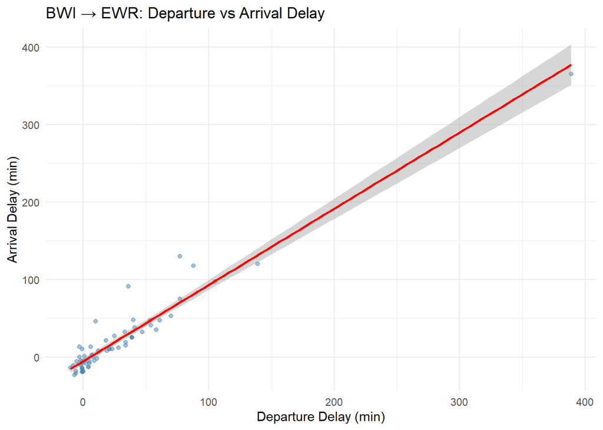

```r
# ============================================================
# Step 5. Regression Models (BWI → EWR & BWI → JFK)
# ============================================================
train_control <- trainControl(method = "cv", number = 5)

# coding and building four regression models for any market pair
run_regression_models <- function(data, route_label) {

  models <- list(
    Linear     = train(arr_delay ~ dep_delay + hour_of_day + is_weekend,
                       data = data, method = "lm",     trControl = train_control),
    Ridge      = train(arr_delay ~ dep_delay + hour_of_day + is_weekend,
                       data = data, method = "glmnet",
                       tuneGrid = expand.grid(alpha = 0, lambda = seq(0, 1, by = 0.1)),
                       trControl = train_control),
    Lasso      = train(arr_delay ~ dep_delay + hour_of_day + is_weekend,
                       data = data, method = "glmnet",
                       tuneGrid = expand.grid(alpha = 1, lambda = seq(0, 1, by = 0.1)),
                       trControl = train_control),
    ElasticNet = train(arr_delay ~ dep_delay + hour_of_day + is_weekend,
                       data = data, method = "glmnet", trControl = train_control)
  )

  # Model comparison
  results <- resamples(models)
  print(dotplot(results, metric = "Rsquared",
                main = paste("Model Comparison: R-squared —", route_label)))

  # Predicted vs Actual
  data$predictions <- predict(models$ElasticNet, newdata = data)
  print(
    ggplot(data, aes(x = arr_delay, y = predictions)) +
      geom_point(alpha = 0.4, color = "darkgreen") +
      geom_abline(slope = 1, intercept = 0, linetype = "dashed", color = "red") +
      labs(title = paste("Elastic Net: Predicted vs. Actual —", route_label),
           x = "Actual Arrival Delay (min)", y = "Predicted Arrival Delay (min)") +
      theme_minimal()
  )

  invisible(models)
}

# --- BWI → EWR ---
market_pair_ewr <- flights_raw %>%
  filter(origin == "BWI", dest == "EWR") %>%
  mutate(
    is_delayed  = as.factor(ifelse(arr_delay > 15, "Yes", "No")),
    hour_of_day = dep_time %/% 100,
    is_weekend  = ifelse(day_of_week %in% c(6, 7), 1, 0)
  ) %>%
  filter(!is.na(arr_delay), !is.na(dep_delay))

ggplot(market_pair_ewr, aes(x = dep_delay, y = arr_delay)) +
  geom_point(alpha = 0.5, color = "steelblue") +
  geom_smooth(method = "lm", color = "red") +
  labs(title = "BWI → EWR: Departure vs Arrival Delay",
       x = "Departure Delay (min)", y = "Arrival Delay (min)") +
  theme_minimal()
```

```r
models_ewr <- run_regression_models(market_pair_ewr, "BWI-EWR")
```

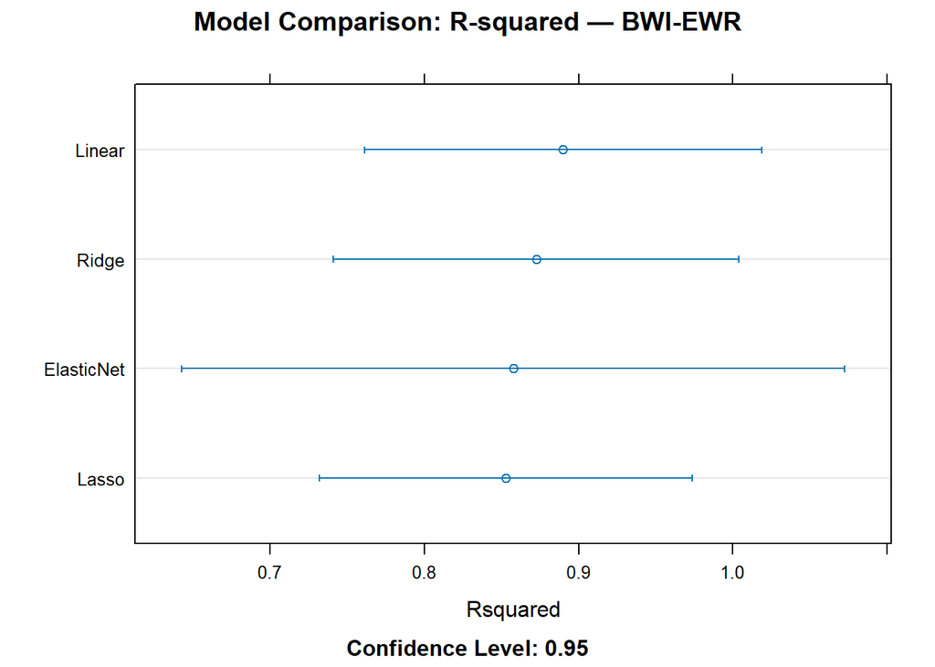

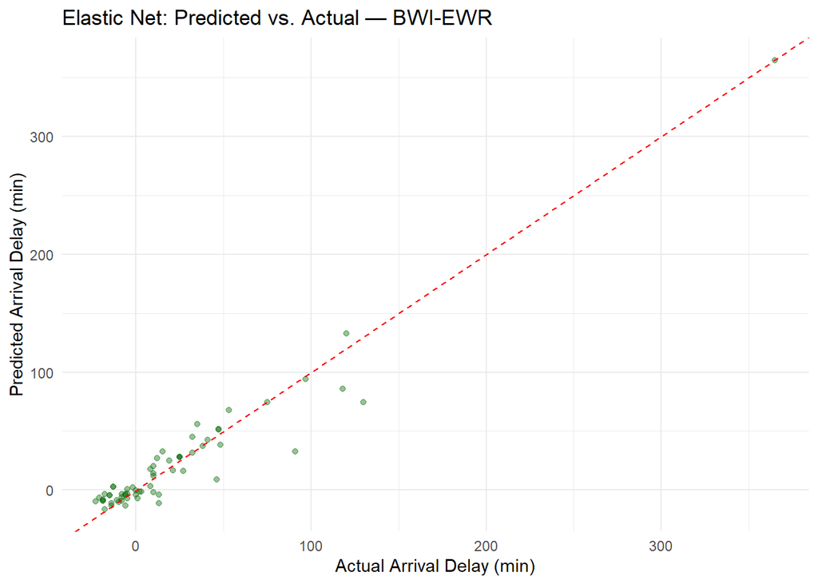

```r
# --- BWI → JFK (primary market pair) ---
market_pair <- flights_raw %>%
  filter(origin == "BWI", dest == "JFK") %>%
  mutate(
    is_delayed  = as.factor(ifelse(arr_delay > 15, "Yes", "No")),
    hour_of_day = dep_time %/% 100,
    is_weekend  = ifelse(day_of_week %in% c(6, 7), 1, 0)
  ) %>%
  filter(!is.na(arr_delay), !is.na(dep_delay), !is.na(hour_of_day))

models_jfk <- run_regression_models(market_pair, "BWI-JFK")
```

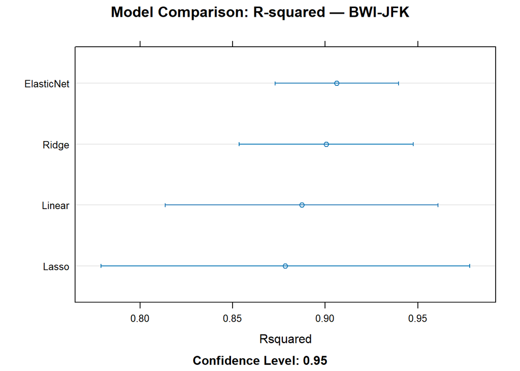

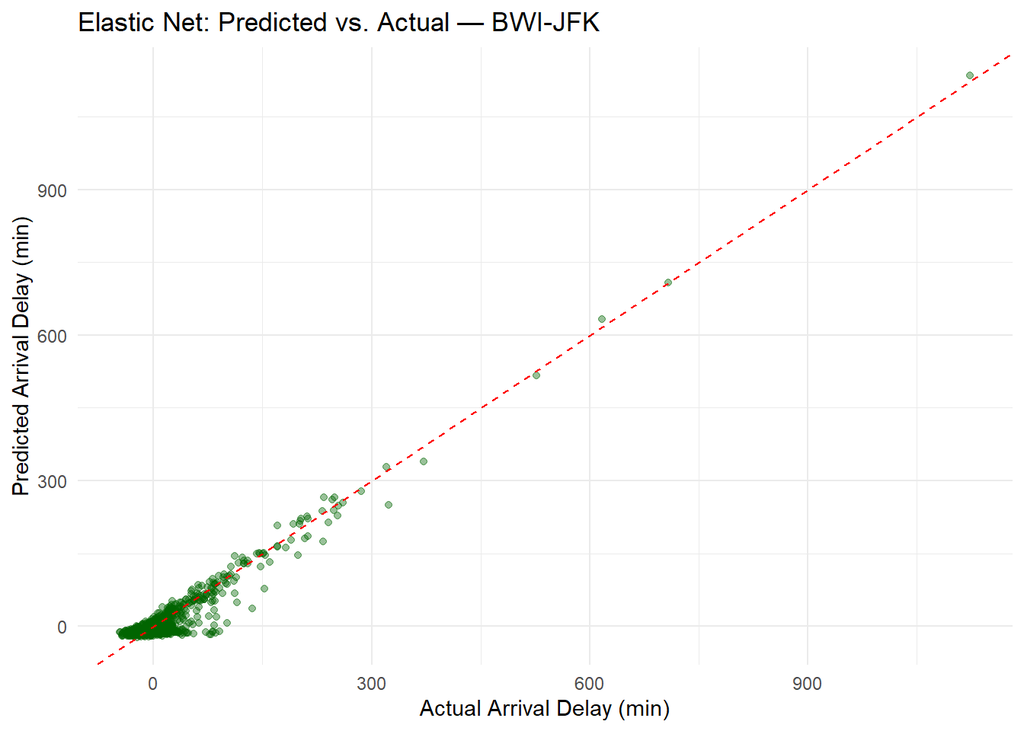

```r
# Logistic regression for classification
model_logit <- train(
  is_delayed ~ dep_delay + hour_of_day + is_weekend,
  data = market_pair, method = "glm", family = "binomial",
  trControl = train_control
)
logit_preds <- predict(model_logit, market_pair)
confusionMatrix(logit_preds, market_pair$is_delayed)
```

```
## Confusion Matrix and Statistics
##
##           Reference
## Prediction   No  Yes
##        No  1464  106
##        Yes   16  194
##
##                Accuracy : 0.9315
##                  95% CI : (0.9187, 0.9428)
##     No Information Rate : 0.8315
##     P-Value [Acc > NIR] : < 2.2e-16
##
##                   Kappa : 0.7222
##
##  Mcnemar's Test P-Value : 7.776e-16
##
##             Sensitivity : 0.9892
##             Specificity : 0.6467
##          Pos Pred Value : 0.9325
##          Neg Pred Value : 0.9238
##              Prevalence : 0.8315
##          Detection Rate : 0.8225
##    Detection Prevalence : 0.8820
##       Balanced Accuracy : 0.8179
##
##        'Positive' Class : No
##
```

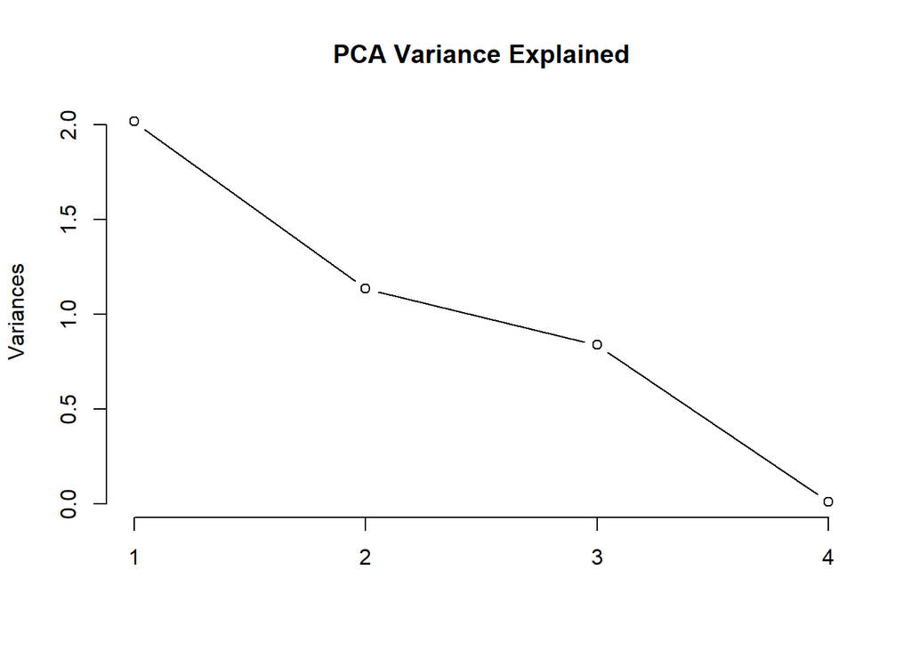

```r
# PCA
pca_input <- market_pair %>%
  select(dep_delay, arr_delay, air_time, distance, taxi_out) %>%
  select(where(~ n_distinct(.) > 1)) %>%
  drop_na()

pca_results <- prcomp(pca_input, scale. = TRUE)
plot(pca_results, type = "l", main = "PCA Variance Explained")
```

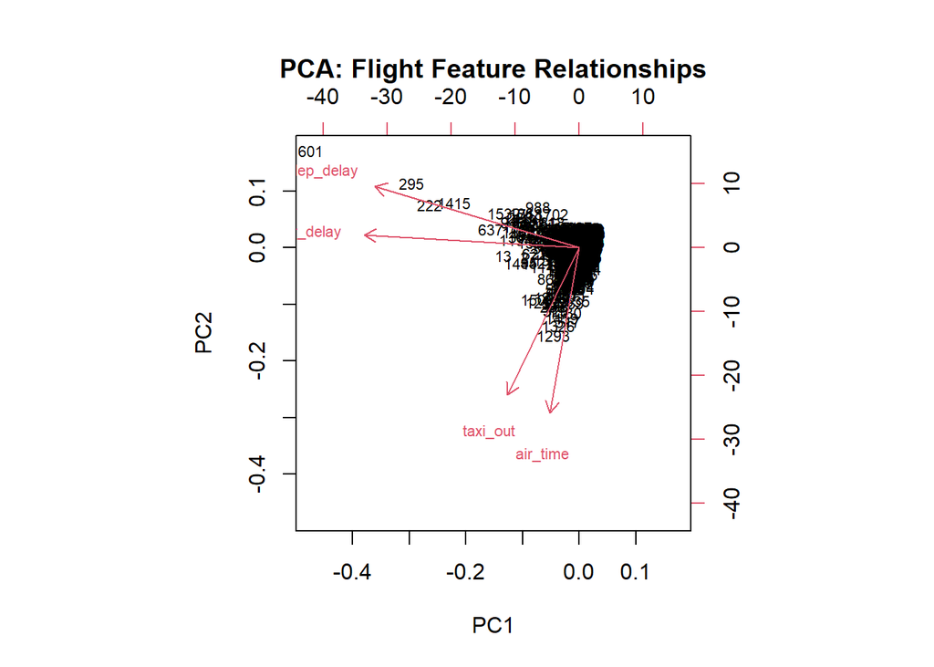

```r
biplot(pca_results, cex = 0.7, main = "PCA: Flight Feature Relationships")
```

```r
# Near-zero variance check
nzv_metrics <- nearZeroVar(market_pair, saveMetrics = TRUE)
print(nzv_metrics)
```

```
##                                 freqRatio percentUnique zeroVar   nzv
## year                             0.000000    0.05617978    TRUE  TRUE
## quarter                          1.011013    0.22471910   FALSE FALSE
## month                            1.051613    0.67415730   FALSE FALSE
## dayof_month                      1.202899    1.74157303   FALSE FALSE
## day_of_week                      1.011494    0.39325843   FALSE FALSE
## flight_date                      1.090909   20.44943820   FALSE FALSE
## reporting_airline                3.759358    0.11235955   FALSE FALSE
## dot_id_reporting_airline         3.759358    0.11235955   FALSE FALSE
## iata_code_reporting_airline      3.759358    0.11235955   FALSE FALSE
## tail_number                      1.071429    6.12359551   FALSE FALSE
## flight_number_reporting_airline  1.695455    1.40449438   FALSE FALSE
## origin_airport_id                0.000000    0.05617978    TRUE  TRUE
## origin_airport_seq_id            0.000000    0.05617978    TRUE  TRUE
## origin_city_market_id            0.000000    0.05617978    TRUE  TRUE
## origin                           0.000000    0.05617978    TRUE  TRUE
## origin_city_name                 0.000000    0.05617978    TRUE  TRUE
## origin_state                     0.000000    0.05617978    TRUE  TRUE
## origin_state_fips                0.000000    0.05617978    TRUE  TRUE
## origin_state_name                0.000000    0.05617978    TRUE  TRUE
## origin_wac                       0.000000    0.05617978    TRUE  TRUE
## dest_airport_id                  0.000000    0.05617978    TRUE  TRUE
## dest_airport_seq_id              0.000000    0.05617978    TRUE  TRUE
## dest_city_market_id              0.000000    0.05617978    TRUE  TRUE
## dest                             0.000000    0.05617978    TRUE  TRUE
## dest_city_name                   0.000000    0.05617978    TRUE  TRUE
## dest_state                       0.000000    0.05617978    TRUE  TRUE
## dest_state_fips                  0.000000    0.05617978    TRUE  TRUE
## dest_state_name                  0.000000    0.05617978    TRUE  TRUE
## dest_wac                         0.000000    0.05617978    TRUE  TRUE
## crs_dep_time                     1.570093    3.14606742   FALSE FALSE
## dep_time                         1.129032   24.15730337   FALSE FALSE
## dep_delay                        1.760000    8.25842697   FALSE FALSE
## dep_delay_minutes               52.769231    7.30337079   FALSE  TRUE
## dep_del15                        6.295082    0.11235955   FALSE FALSE
## departure_delay_groups           6.097222    0.84269663   FALSE FALSE
## dep_time_blk                     1.059659    0.67415730   FALSE FALSE
## taxi_out                         1.153846    4.66292135   FALSE FALSE
## wheels_off                       1.157895   28.20224719   FALSE FALSE
## wheels_on                        1.312500   29.21348315   FALSE FALSE
```

[output cut: 160 more lines]

```
## engine_code                      1.857477    0.50561798   FALSE FALSE
## engine_type                     10.152866    0.16853933   FALSE FALSE
## engine_manufacturer              4.561338    0.22471910   FALSE FALSE
## engine_model                     1.857477    0.50561798   FALSE FALSE
## engine_power_hp                  0.000000    0.05617978    TRUE  TRUE
## engine_thrust_lbf                1.857477    0.39325843   FALSE FALSE
## manufacturing_year               1.875000    0.61797753   FALSE FALSE
## registrant_type                  1.872566    0.16853933   FALSE FALSE
## registrant_name                  1.113022    0.56179775   FALSE FALSE
## registrant_city                  1.388206    0.44943820   FALSE FALSE
## registrant_state                 1.388206    0.44943820   FALSE FALSE
## registrant_country              10.337580    0.11235955   FALSE FALSE
## is_delayed                       4.933333    0.11235955   FALSE FALSE
## hour_of_day                      1.356846    1.06741573   FALSE FALSE
## is_weekend                       2.469786    0.11235955   FALSE FALSE
```

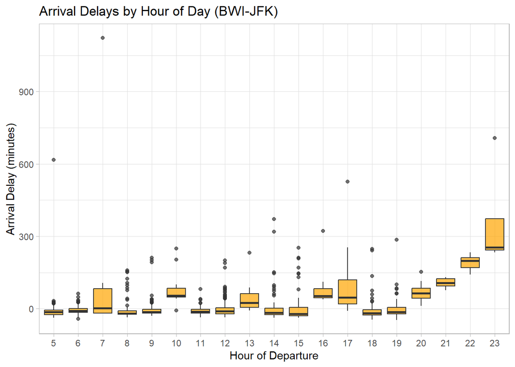

```r
# Arrival delays by hour of day
ggplot(market_pair, aes(x = as.factor(hour_of_day), y = arr_delay)) +
  geom_boxplot(fill = "orange", alpha = 0.7) +
  labs(title = "Arrival Delays by Hour of Day (BWI-JFK)",
       x = "Hour of Departure", y = "Arrival Delay (minutes)") +
  theme_light()
```

## Step 6 Delays

**NOTES:**  
group_by(tail_number, flight_date) - after looking at the flight delays, looking at tail number (plane registration) we are able to track the plane and see if one if that affected the delay;  
Turnaround min - when it landed and when it took off to find the gap between;  
prev_flight_delayed - was the plane delayed getting to destination;  
ggplot - for visualization.

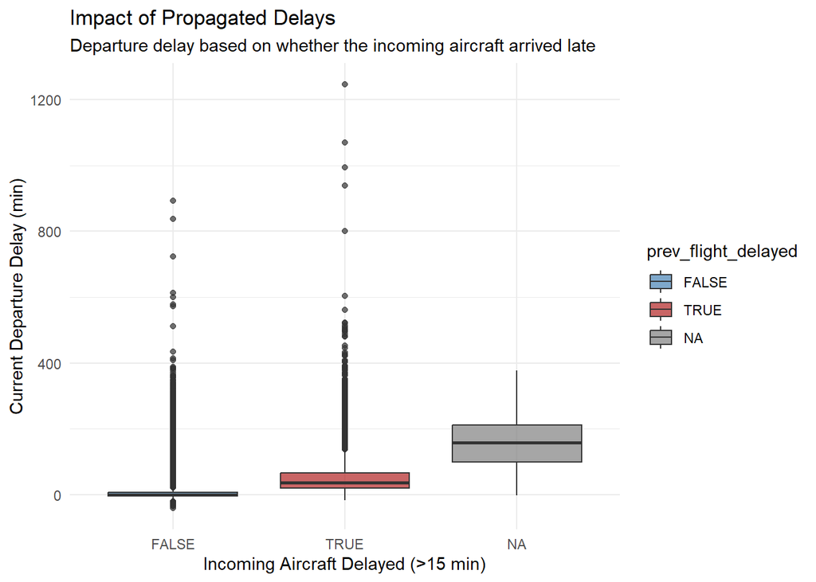

```r
# ============================================================
# Step 6. Propagated Delays - looking at tail number analysis
# ============================================================
propagated_delays <- flights_raw %>%
  filter(!is.na(tail_number), !is.na(wheels_on), !is.na(wheels_off)) %>%
  select(tail_number, flight_date, origin, dest,
         wheels_on, wheels_off, arr_delay, dep_delay) %>%
  arrange(tail_number, flight_date, wheels_off) %>%
  group_by(tail_number, flight_date) %>%
  mutate(
    prev_flight_arrival = lag(wheels_on),
    turnaround_mins = as.numeric(difftime(
      strptime(sprintf("%04d", wheels_off),         format = "%H%M"),
      strptime(sprintf("%04d", prev_flight_arrival), format = "%H%M"),
      units = "mins"
    )),
    prev_flight_delayed = lag(arr_delay) > 15
  ) %>%
  filter(!is.na(turnaround_mins), turnaround_mins > 0)

ggplot(propagated_delays, aes(x = prev_flight_delayed, y = dep_delay, fill = prev_flight_delayed)) +
  geom_boxplot(alpha = 0.7) +
  labs(
    title    = "Impact of Propagated Delays",
    subtitle = "Departure delay based on whether the incoming aircraft arrived late",
    x = "Incoming Aircraft Delayed (>15 min)", y = "Current Departure Delay (min)"
  ) +
  scale_fill_manual(values = c("steelblue", "firebrick")) +
  theme_minimal()
```

```r
propagated_delays %>%
  group_by(prev_flight_delayed) %>%
  summarise(
    avg_dep_delay      = mean(dep_delay,        na.rm = TRUE),
    median_turnaround  = median(turnaround_mins, na.rm = TRUE),
    flight_count       = n()
  )
```

```
## # A tibble: 3 × 4
##   prev_flight_delayed avg_dep_delay median_turnaround flight_count
##   <lgl>                       <dbl>             <dbl>        <int>
## 1 FALSE                        5.44                77        86124
## 2 TRUE                        52.4                 69        13143
## 3 NA                         156.                  82          142
```

## Step 7 Taxi-Out Time  
**NOTES:**  
group by - hour of day in 24h period to get average and median;  
flight count - it ignores hours that had 5 or less flights;  
taxi_corr - correlation calculation,  
ggplot - to visualize data;  
Results: best time to fly woul dbe at 7am, least amout of taxi time; worst time after 4pm.\

```r
# ============================================================
# Step 7. TAXI-OUT - how long the plane is on turmac/congestion
# (BWI → JFK)
# ============================================================
taxi_summary <- market_pair %>%
  group_by(hour_of_day) %>%
  summarise(
    avg_taxi_out    = mean(taxi_out,   na.rm = TRUE),
    median_taxi_out = median(taxi_out, na.rm = TRUE),
    flight_count    = n()
  ) %>%
  filter(flight_count > 5)

taxi_corr <- cor(market_pair$hour_of_day, market_pair$taxi_out, use = "complete.obs")
message("Correlation (Hour of Day vs Taxi-Out): ", round(taxi_corr, 3))
```

```
## Correlation (Hour of Day vs Taxi-Out): 0.082
```

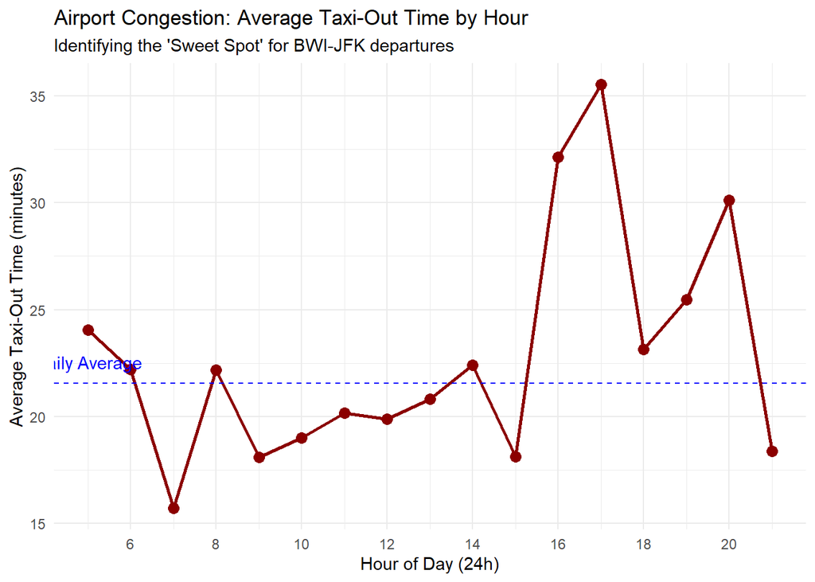

```r
ggplot(taxi_summary, aes(x = hour_of_day, y = avg_taxi_out)) +
  geom_line(color = "darkred", linewidth = 1) +
  geom_point(size = 3, color = "darkred") +
  geom_hline(yintercept = mean(market_pair$taxi_out, na.rm = TRUE),
             linetype = "dashed", color = "blue") +
  annotate("text", x = 5,
           y = mean(market_pair$taxi_out, na.rm = TRUE) + 1,
           label = "Daily Average", color = "blue") +
  scale_x_continuous(breaks = seq(0, 23, by = 2)) +
  labs(
    title    = "Airport Congestion: Average Taxi-Out Time by Hour",
    subtitle = "Identifying the 'Sweet Spot' for BWI-JFK departures",
    x = "Hour of Day (24h)", y = "Average Taxi-Out Time (minutes)"
  ) +
  theme_minimal()
```

## Step 8 Weather impact

**NOTES:**  
grouping by - weather severity;  
LM and coef - linear model and multiplier;  
Looking at the impact of weather on delays depending on severity.  
ggplot - to view the results.

```r
# ============================================================
# Step 8. Looking at weather impact
# ============================================================
weather_summary <- market_pair %>%
  group_by(dep_weather_severity) %>%
  summarise(avg_dep_delay = mean(dep_delay, na.rm = TRUE), flight_count = n()) %>%
  filter(!is.na(dep_weather_severity))

weather_model  <- lm(dep_delay ~ dep_weather_severity, data = market_pair)
multiplier     <- coef(weather_model)["dep_weather_severity"]
message("Weather Multiplier: ", round(multiplier, 2), " minutes per severity level")
```

```
## Weather Multiplier: -2.17 minutes per severity level
```

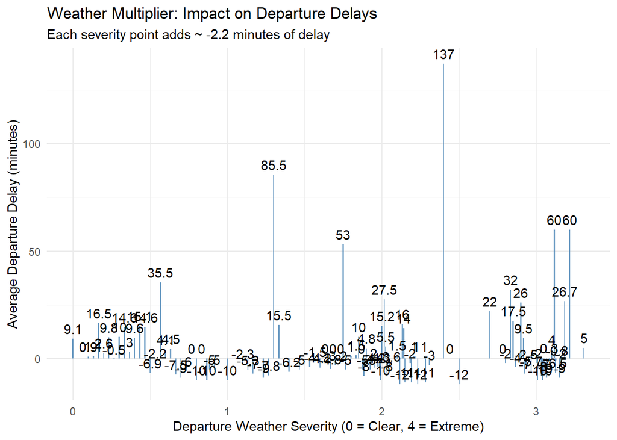

```r
ggplot(weather_summary, aes(x = dep_weather_severity, y = avg_dep_delay)) +
  geom_col(fill = "steelblue", alpha = 0.8) +
  geom_text(aes(label = round(avg_dep_delay, 1)), vjust = -0.5) +
  labs(
    title    = "Weather Multiplier: Impact on Departure Delays",
    subtitle = paste("Each severity point adds ~", round(multiplier, 1), "minutes of delay"),
    x = "Departure Weather Severity (0 = Clear, 4 = Extreme)",
    y = "Average Departure Delay (minutes)"
  ) +
  theme_minimal()
```

## Step 9 Scheduling Strategy

**NOTES:** in this test I will check which airline adds time to thier schedule to allow times for delays.  
time buffer - what is actual time and schedyled time of departure;  
summarise - how many flights arrived on time, how many were late, in the review looking at airline that shows over 1000 flights;  
ggplot - to visualize results.  
Results: 9E (Endavor Air by Delta) with flight count of 1406 show over 71.4% arrivals on time.

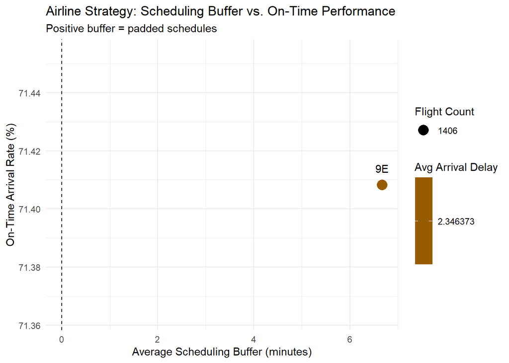

```r
# ============================================================
# Step 9. Airline Buffer and Scheduling Strategy
# ============================================================
airline_buffer <- market_pair %>%
  mutate(
    time_buffer = crs_elapsed_time - actual_elapsed_time,
    is_on_time  = arr_delay <= 0
  ) %>%
  group_by(reporting_airline) %>%
  summarise(
    avg_buffer    = mean(time_buffer, na.rm = TRUE),
    on_time_rate  = mean(is_on_time,  na.rm = TRUE) * 100,
    avg_arr_delay = mean(arr_delay,   na.rm = TRUE),
    flight_count  = n()
  ) %>%
  filter(flight_count > 1000)

ggplot(airline_buffer, aes(x = avg_buffer, y = on_time_rate, label = reporting_airline)) +
  geom_point(aes(size = flight_count, color = avg_arr_delay)) +
  geom_text(vjust = -1.5) +
  geom_vline(xintercept = 0, linetype = "dashed") +
  scale_color_gradient(low = "darkgreen", high = "red") +
  labs(
    title    = "Airline Strategy: Scheduling Buffer vs. On-Time Performance",
    subtitle = "Positive buffer = padded schedules",
    x = "Average Scheduling Buffer (minutes)", y = "On-Time Arrival Rate (%)",
    color = "Avg Arrival Delay", size = "Flight Count"
  ) +
  theme_minimal()
```

## Step 10 Scheduling

```r
# ============================================================
# Step 10. Scheduling honesty (BWI → JFK)
# ============================================================
honesty_summary <- market_pair %>%
  filter(reporting_airline %in% c("9E", "AA", "B6")) %>%
  mutate(
    time_buffer  = crs_elapsed_time - actual_elapsed_time,
    Carrier_Name = case_when(
      reporting_airline == "9E" ~ "Endeavor (Delta)",
      reporting_airline == "B6" ~ "JetBlue",
      reporting_airline == "AA" ~ "American",
      TRUE                      ~ reporting_airline
    )
  ) %>%
  group_by(reporting_airline, Carrier_Name) %>%
  summarise(
    Avg_Buffer         = round(mean(time_buffer, na.rm = TRUE),          1),
    On_Time_Rate       = round(mean(arr_delay <= 0, na.rm = TRUE) * 100, 1),
    Avg_Arrival_Delay  = round(mean(arr_delay, na.rm = TRUE),            1),
    .groups = "drop"
  ) %>%
  mutate(Strategy = case_when(
    Avg_Buffer >  8 ~ "Realistic (High Padding)",
    Avg_Buffer >  0 ~ "Balanced",
    TRUE            ~ "Optimistic (Risky)"
  )) %>%
  rename(
    `Airline Code`            = reporting_airline,
    `Carrier Name`            = Carrier_Name,
    `Avg Buffer (Mins)`       = Avg_Buffer,
    `On-Time Rate (%)`        = On_Time_Rate,
    `Avg Arrival Delay (Mins)`= Avg_Arrival_Delay
  )

kable(honesty_summary, format = "html",
      caption = "BWI-JFK Airline Scheduling Honesty Comparison") %>%
  kable_styling(bootstrap_options = c("striped", "hover", "condensed"), full_width = FALSE) %>%
  column_spec(3, bold = TRUE,  color = "white", background = "#2c3e50") %>%
  column_spec(6, italic = TRUE)
```

BWI-JFK Airline Scheduling Honesty Comparison

| Airline Code | Carrier Name | Avg Buffer (Mins) | On-Time Rate (%) | Avg Arrival Delay (Mins) | Strategy |
| --- | --- | --- | --- | --- | --- |
| 9E | Endeavor (Delta) | 6.7 | 71.4 | 2.3 | Balanced |

## Step 11 Market Share  
**NOTES:**  
Since 9E belongs to Delta, I wanted to see howm any flights they have out of BWI. Results show 79% of the market.

```r
# ============================================================
# Step 11. Market Share — Delta vs. Others (BWI → JFK)
# ============================================================
delta_comparison <- market_pair %>%
  mutate(Carrier_Group = ifelse(reporting_airline %in% c("DL", "9E"),
                                "Delta / Endeavor", "Other Carriers")) %>%
  group_by(Carrier_Group) %>%
  summarise(Flight_Count = n(), .groups = "drop") %>%
  mutate(Percentage = round(Flight_Count / sum(Flight_Count) * 100, 1))

print(delta_comparison)
```

```
## # A tibble: 2 × 3
##   Carrier_Group    Flight_Count Percentage
##   <chr>                   <int>      <dbl>
## 1 Delta / Endeavor         1406         79
## 2 Other Carriers            374         21
```

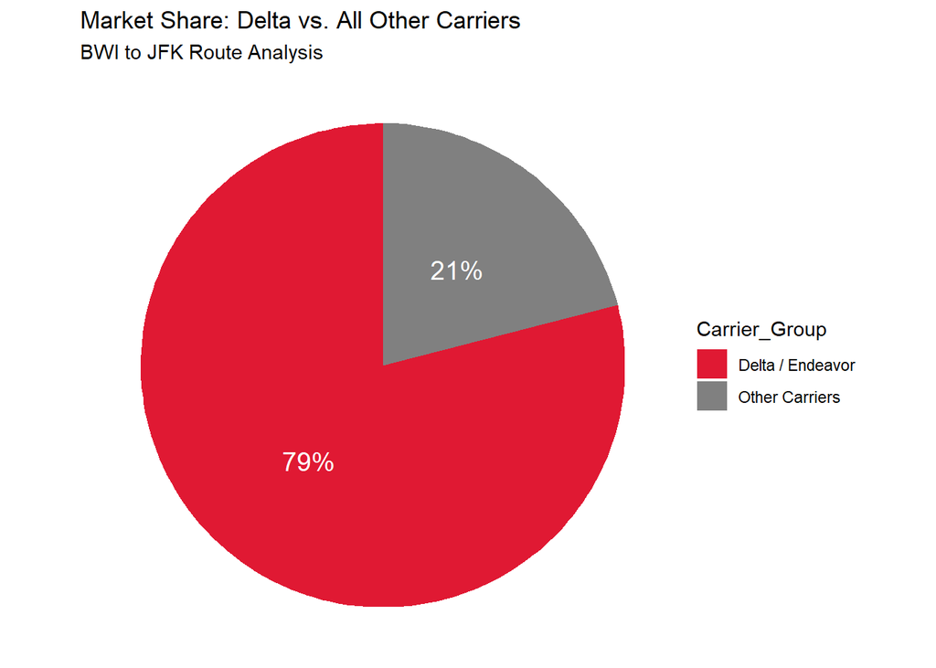

```r
ggplot(delta_comparison, aes(x = "", y = Flight_Count, fill = Carrier_Group)) +
  geom_bar(stat = "identity", width = 1) +
  coord_polar("y", start = 0) +
  scale_fill_manual(values = c("#E01933", "#808080")) +
  geom_text(aes(label = paste0(Percentage, "%")),
            position = position_stack(vjust = 0.5), color = "white", size = 5) +
  labs(title    = "Market Share: Delta vs. All Other Carriers",
       subtitle = "BWI to JFK Route Analysis") +
  theme_void()
```

## Step 12 Carrier Volume

**NOTES:**  
Here I’m looking at all the flights, no mater where to and from. Counting the rows for each airline.

```r
# ============================================================
# Step 12. Carrier Volume on all routes
# ============================================================
global_carrier_stats <- flights_raw %>%
  group_by(reporting_airline) %>%
  summarise(Total_Records = n(), .groups = "drop") %>%
  mutate(
    Global_Share = round(Total_Records / sum(Total_Records) * 100, 1),
    Carrier_Name = case_when(
      reporting_airline == "9E" ~ "Endeavor (Delta)",
      reporting_airline == "DL" ~ "Delta Mainline",
      reporting_airline == "AA" ~ "American",
      reporting_airline == "B6" ~ "JetBlue",
      reporting_airline == "WN" ~ "Southwest",
      reporting_airline == "UA" ~ "United",
      reporting_airline == "OO" ~ "SkyWest",
      reporting_airline == "YX" ~ "Republic",
      TRUE                      ~ reporting_airline
    )
  ) %>%
  arrange(desc(Total_Records))

print(head(global_carrier_stats, 10))
```

```
## # A tibble: 10 × 4
##    reporting_airline Total_Records Global_Share Carrier_Name
##    <chr>                     <int>        <dbl> <chr>
##  1 WN                       149840         67.2 Southwest
##  2 NK                        20843          9.4 NK
##  3 DL                        14727          6.6 Delta Mainline
##  4 AA                        12602          5.7 American
##  5 UA                         7249          3.3 United
##  6 9E                         5984          2.7 Endeavor (Delta)
##  7 B6                         3936          1.8 JetBlue
##  8 AS                         3139          1.4 AS
##  9 MQ                         1905          0.9 MQ
## 10 G4                          855          0.4 G4
```

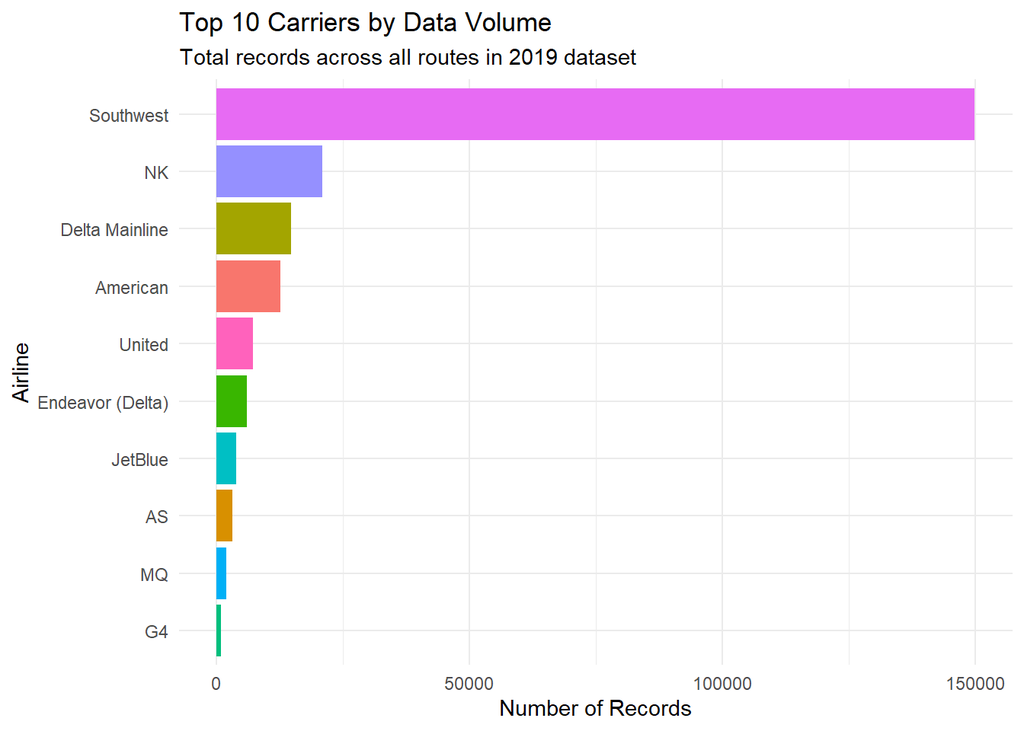

```r
ggplot(head(global_carrier_stats, 10),
       aes(x = reorder(Carrier_Name, Total_Records), y = Total_Records, fill = Carrier_Name)) +
  geom_col() +
  coord_flip() +
  labs(title    = "Top 10 Carriers by Data Volume",
       subtitle = "Total records across all routes in 2019 dataset",
       x = "Airline", y = "Number of Records") +
  theme_minimal() +
  theme(legend.position = "none")
```

## Step 13 Buffers and Scheduling

**NOTES:**  
Since Southwest had the most volume, I will look at their buffer and scheduling.

```r
# ============================================================
# Step 13. Southwest Buffers & Scheduling Strategy - all
# ============================================================
southwest_strategy <- flights_raw %>%
  filter(reporting_airline == "WN") %>%
  mutate(time_buffer = crs_elapsed_time - actual_elapsed_time) %>%
  summarise(
    Avg_Buffer    = round(mean(time_buffer,        na.rm = TRUE), 1),
    Median_Buffer = round(median(time_buffer,      na.rm = TRUE), 1),
    On_Time_Rate  = round(mean(arr_delay <= 0,     na.rm = TRUE) * 100, 1),
    Total_Flights = n()
  )

message("Global Southwest Strategy:")
```

```
## Global Southwest Strategy:
```

```r
print(southwest_strategy)
```

```
## # A tibble: 1 × 4
##   Avg_Buffer Median_Buffer On_Time_Rate Total_Flights
##        <dbl>         <dbl>        <dbl>         <int>
## 1        8.7            10         68.5        149840
```

```r
sw_padded_routes <- flights_raw %>%
  filter(reporting_airline == "WN") %>%
  mutate(time_buffer = crs_elapsed_time - actual_elapsed_time) %>%
  group_by(origin, dest) %>%
  summarise(
    Avg_Buffer   = round(mean(time_buffer, na.rm = TRUE), 1),
    Flight_Count = n(),
    .groups = "drop"
  ) %>%
  filter(Flight_Count > 50) %>%
  arrange(desc(Avg_Buffer)) %>%
  head(5)

kable(sw_padded_routes,
      caption = "Top 5 Southwest Routes with Most Buffer (Padding)") %>%
  kable_styling(bootstrap_options = c("striped", "hover"))
```

Top 5 Southwest Routes with Most Buffer (Padding)

| origin | dest | Avg_Buffer | Flight_Count |
| --- | --- | --- | --- |
| GSP | BWI | 16.0 | 63 |
| BWI | OAK | 15.8 | 385 |
| SAN | BWI | 14.0 | 1016 |
| BWI | GSP | 13.4 | 61 |
| LAX | BWI | 13.3 | 1130 |

## Step 14 Comparision

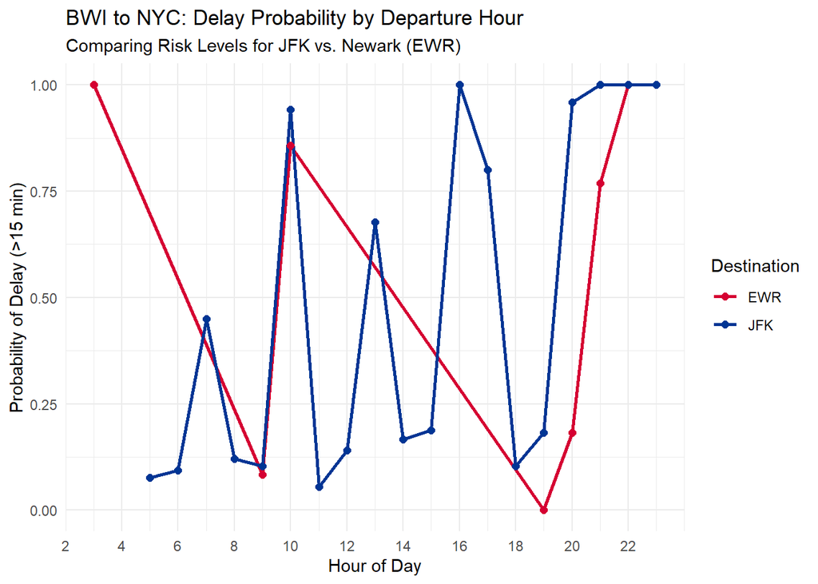

```r
# ============================================================
# Step 14. Comparative Analysis: BWI → JFK vs. BWI → EWR
# ============================================================

# --- Create Comparative Subset ---
nyc_comparison <- flights_raw %>%
  filter(origin == "BWI", dest %in% c("JFK", "EWR")) %>%
  mutate(
    hour_of_day = dep_time %/% 100,
    is_delayed  = arr_delay > 15,
    time_buffer = crs_elapsed_time - actual_elapsed_time
  ) %>%
  filter(!is.na(arr_delay), !is.na(hour_of_day))

# --- Visualizing Delay Probability by Hour ---
# which NYC airport becomes "riskier" at which time
ggplot(nyc_comparison, aes(x = hour_of_day, y = as.numeric(is_delayed), color = dest)) +
  stat_summary(fun = mean, geom = "line", linewidth = 1) +
  stat_summary(fun = mean, geom = "point", size = 2) +
  scale_x_continuous(breaks = seq(0, 23, by = 2)) +
  scale_color_manual(values = c("JFK" = "#003594", "EWR" = "#D50032")) + # Airline-style colors
  labs(
    title = "BWI to NYC: Delay Probability by Departure Hour",
    subtitle = "Comparing Risk Levels for JFK vs. Newark (EWR)",
    x = "Hour of Day", y = "Probability of Delay (>15 min)",
    color = "Destination"
  ) +
  theme_minimal()
```

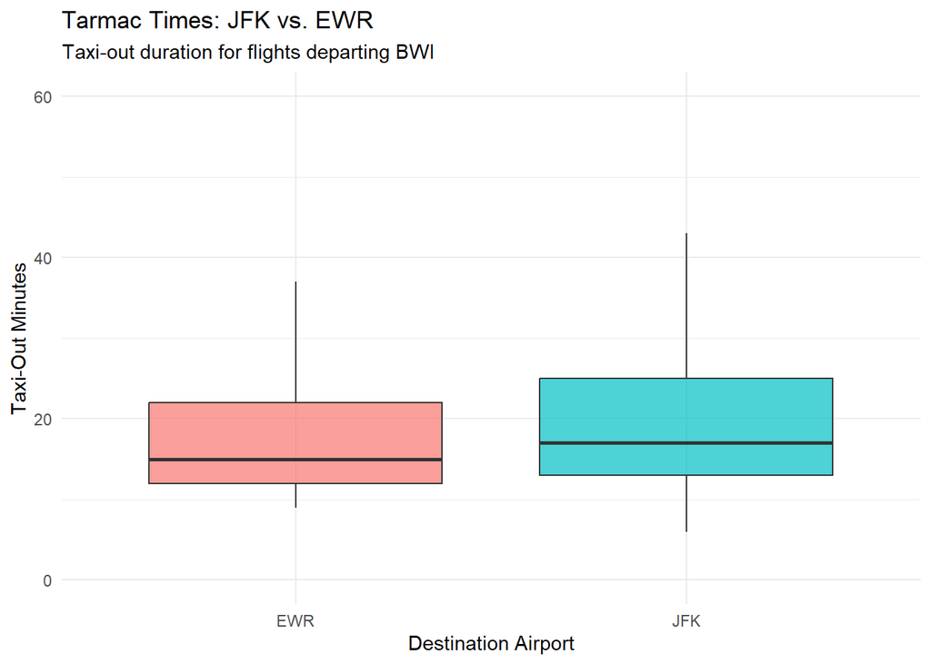

```r
# --- Taxi-Out Comparison (Airport Congestion) ---
# which airport has worse tarmac congestion
ggplot(nyc_comparison, aes(x = dest, y = taxi_out, fill = dest)) +
  geom_boxplot(alpha = 0.7, outlier.shape = NA) +
  coord_cartesian(ylim = c(0, 60)) +
  labs(
    title = "Tarmac Times: JFK vs. EWR",
    subtitle = "Taxi-out duration for flights departing BWI",
    x = "Destination Airport", y = "Taxi-Out Minutes"
  ) +
  theme_minimal() +
  guides(fill = "none")
```

```r
# --- Summary Table Comparison ---
nyc_summary_table <- nyc_comparison %>%
  group_by(dest) %>%
  summarise(
    Total_Flights   = n(),
    Avg_Arrival_Delay = round(mean(arr_delay, na.rm = TRUE), 1),
    On_Time_Rate     = round(mean(arr_delay <= 0, na.rm = TRUE) * 100, 1),
    Avg_Taxi_Out     = round(mean(taxi_out, na.rm = TRUE), 1),
    Avg_Buffer       = round(mean(time_buffer, na.rm = TRUE), 1)
  )

kable(nyc_summary_table, caption = "BWI to NYC Hubs: Side-by-Side Performance") %>%
  kable_styling(bootstrap_options = c("striped", "hover"))
```

BWI to NYC Hubs: Side-by-Side Performance

| dest | Total_Flights | Avg_Arrival_Delay | On_Time_Rate | Avg_Taxi_Out | Avg_Buffer |
| --- | --- | --- | --- | --- | --- |
| EWR | 63 | 21.8 | 42.9 | 18.9 | 5.9 |
| JFK | 1780 | 1.6 | 71.6 | 21.5 | 6.3 |

## Step 15 Reliability  
**NOTES:**  
checking which airline is most reliable from the dataset.  
Looking at :  
- on time rate;  
- extreme delay rate;  
- flierting by m=numnber of flights > 20.  
ggplot - to visualize data  
Results: 9E over 80% on time rate with average delay of less than 5 min, MQ over 85% on time.

[figure not shown]

```r
# ============================================================
# Step 15. How reliable are : BWI → JFK/EWR
# ============================================================

# --- Calculate Reliability Metrics ---
reliability_leaderboard <- nyc_comparison %>%
  group_by(reporting_airline, dest) %>%
  summarise(
    Flight_Count = n(),
    On_Time_Rate = mean(arr_delay <= 15, na.rm = TRUE) * 100,
    Avg_Delay_Mins = mean(arr_delay, na.rm = TRUE),
    Extreme_Delay_Rate = mean(arr_delay > 60, na.rm = TRUE) * 100, # % of flights > 1 hour late
    .groups = "drop"
  ) %>%
  filter(Flight_Count > 20) %>% # Filter for statistical significance
  arrange(desc(On_Time_Rate))

# --- Visualizing Reliability (On-Time vs. Severity) ---
ggplot(reliability_leaderboard, aes(x = On_Time_Rate, y = Avg_Delay_Mins, label = reporting_airline)) +
  geom_point(aes(size = Flight_Count, color = dest), alpha = 0.7) +
  geom_text(vjust = -1.2, check_overlap = TRUE) +
  scale_color_manual(values = c("JFK" = "#003594", "EWR" = "#D50032")) +
  labs(
    title = "Reliability Leaderboard: BWI to JFK & EWR",
    subtitle = "Top-Left = Most Reliable (High On-Time, Low Delay Severity)",
    x = "On-Time Arrival Rate (%)",
    y = "Average Arrival Delay (Minutes)",
    color = "Destination",
    size = "Volume"
  ) +
  theme_minimal()
```

```r
# --- Recommendation Table ---
reliability_leaderboard %>%
  mutate(
    Reliability_Score = (On_Time_Rate / 10) - (Extreme_Delay_Rate / 5),
    Status = case_when(
      Reliability_Score > 8 ~ "Elite",
      Reliability_Score > 6 ~ "Stable",
      TRUE ~ "Volatile"
    )
  ) %>%
  select(reporting_airline, dest, On_Time_Rate, Extreme_Delay_Rate, Status) %>%
  kable(caption = "The BWI-NYC Reliability Index") %>%
  kable_styling(bootstrap_options = c("striped", "hover"))
```

The BWI-NYC Reliability Index

| reporting_airline | dest | On_Time_Rate | Extreme_Delay_Rate | Status |
| --- | --- | --- | --- | --- |
| MQ | JFK | 86.09626 | 5.347594 | Stable |
| 9E | JFK | 82.36131 | 6.827881 | Stable |
| WN | EWR | 63.49206 | 11.111111 | Volatile |

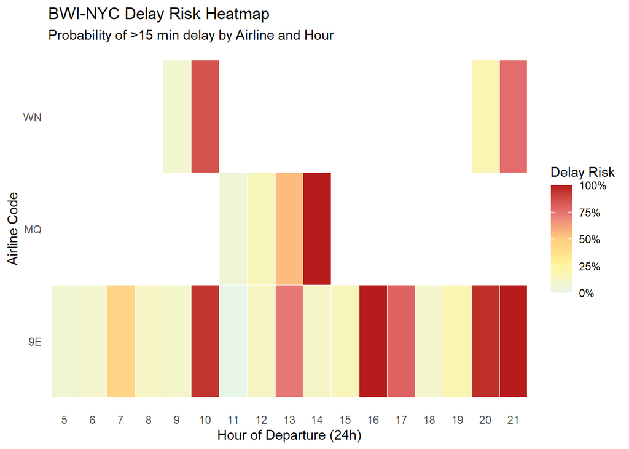

```r
# ============================================================
# Step 16. Delay Risk Heatmap: airline X hour of the day
# ============================================================

# --- Prepare Heatmap Data ---
heatmap_data <- nyc_comparison %>%
group_by(reporting_airline, hour_of_day) %>%
summarise(
delay_prob = mean(is_delayed, na.rm = TRUE),
 flight_count = n(),
.groups = "drop"
 ) %>%
# Filter out low-volume combinations to avoid "noise"
 filter(flight_count > 5)

# --- Create the Heatmap ---
ggplot(heatmap_data, aes(x = factor(hour_of_day), y = reporting_airline, fill = delay_prob)) +
   geom_tile(color = "white") +
   scale_fill_gradientn(
     colors = c("#e8f5e9", "#fff59d", "#ffcc80", "#e57373", "#b71c1c"),
     labels = scales::percent,
     name = "Delay Risk"
   ) +
   labs(
    title = "BWI-NYC Delay Risk Heatmap",
    subtitle = "Probability of >15 min delay by Airline and Hour",
    x = "Hour of Departure (24h)",
     y = "Airline Code"
   ) +
   theme_minimal() +
  theme(
    panel.grid = element_blank(),
     axis.text.x = element_text(angle = 0)
   )
```